# Group Project #2

# Political Views Trees

Now lets repeat the process with polviwes as our response variable.

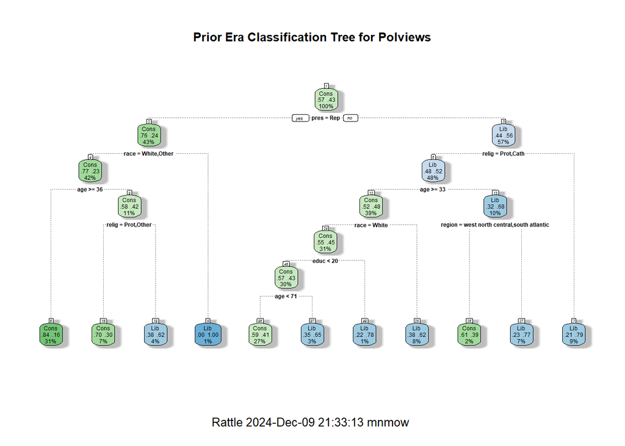

```r
gss$polviews <- factor(gss$polviews, levels = c(0, 1), labels = c("Cons", "Lib"))
gss$confed <- factor(gss$confed, levels = c(0, 1), labels = c("Trust", "No Trust"))
gss$pres <- factor(gss$pres, levels = c(0, 1), labels = c("Rep", "Dem"))


# Split training and test data sets
gss_split <- initial_split(gss[gss$era == 0,], prop = 0.70, strata = polviews)
gss_test <- testing(gss_split)
gss_train <- training(gss_split)

#Build Tree using Political Categories
set.seed(1)
gssfit <- rpart(polviews ~ sex + age + race + relig + region + income + educ + incumbency + pres + confed, data=gss_train, method="class")
fancyRpartPlot(gssfit, main = "Prior Era Classification Tree for Polviews")
```

```r
# Testing and Validation
pred <- predict(gssfit, gss_test, type = "class")
pmat0 <- confusionMatrix(gss_test$polviews, pred)
pmat0
```

```
## Confusion Matrix and Statistics
##
##           Reference
## Prediction Cons Lib
##       Cons  144  40
##       Lib    75  61
##
##                Accuracy : 0.6406
##                  95% CI : (0.5854, 0.6932)
##     No Information Rate : 0.6844
##     P-Value [Acc > NIR] : 0.958222
##
##                   Kappa : 0.2392
##
##  Mcnemar's Test P-Value : 0.001522
##
##             Sensitivity : 0.6575
##             Specificity : 0.6040
##          Pos Pred Value : 0.7826
##          Neg Pred Value : 0.4485
##              Prevalence : 0.6844
##          Detection Rate : 0.4500
##    Detection Prevalence : 0.5750
##       Balanced Accuracy : 0.6307
##
##        'Positive' Class : Cons
##
```

```r
# Split training and test data sets
gss_split <- initial_split(gss[gss$era == 1,], prop = 0.70, strata = confed)
gss_test <- testing(gss_split)
gss_train <- training(gss_split)

#Build Tree using Political Categories
set.seed(1)
gssfit <- rpart(polviews ~ sex + age + race + relig + region + income + educ + incumbency + pres + confed, data=gss_train, method="class")
summary(gssfit)
```

```
## Call:
## rpart(formula = polviews ~ sex + age + race + relig + region +
##     income + educ + incumbency + pres + confed, data = gss_train,
##     method = "class")
##   n= 828
##
##          CP nsplit rel error    xerror       xstd
## 1 0.7774799      0 1.0000000 1.0000000 0.03838275
## 2 0.0100000      1 0.2225201 0.2225201 0.02316825
##
## Variable importance
##   pres  relig   race   educ region    age
##     49     16     11      9      8      8
##
## Node number 1: 828 observations,    complexity param=0.7774799
##   predicted class=Cons  expected loss=0.4504831  P(node) =1
##     class counts:   455   373
##    probabilities: 0.550 0.450
##   left son=2 (424 obs) right son=3 (404 obs)
##   Primary splits:
##       pres   splits as  LR, improve=263.21250, (0 missing)
##       relig  splits as  LLRRLRLRLLL--, improve= 67.30021, (0 missing)
##       educ   < 14.5 to the left,  improve= 19.25295, (0 missing)
##       age    < 43.5 to the right, improve= 16.83277, (0 missing)
##       region splits as  RRRLLLLRR, improve= 14.04541, (0 missing)
##   Surrogate splits:
##       relig  splits as  LLRRRRRRRLL--, agree=0.671, adj=0.327, (0 split)
##       race   splits as  LRR, agree=0.620, adj=0.220, (0 split)
##       educ   < 14.5 to the left,  agree=0.600, adj=0.181, (0 split)
##       region splits as  LRRLLLLRR, agree=0.594, adj=0.168, (0 split)
##       age    < 52.5 to the right, agree=0.588, adj=0.156, (0 split)
##
## Node number 2: 424 observations
##   predicted class=Cons  expected loss=0.06132075  P(node) =0.5120773
##     class counts:   398    26
##    probabilities: 0.939 0.061
##
## Node number 3: 404 observations
##   predicted class=Lib   expected loss=0.1410891  P(node) =0.4879227
##     class counts:    57   347
##    probabilities: 0.141 0.859
```

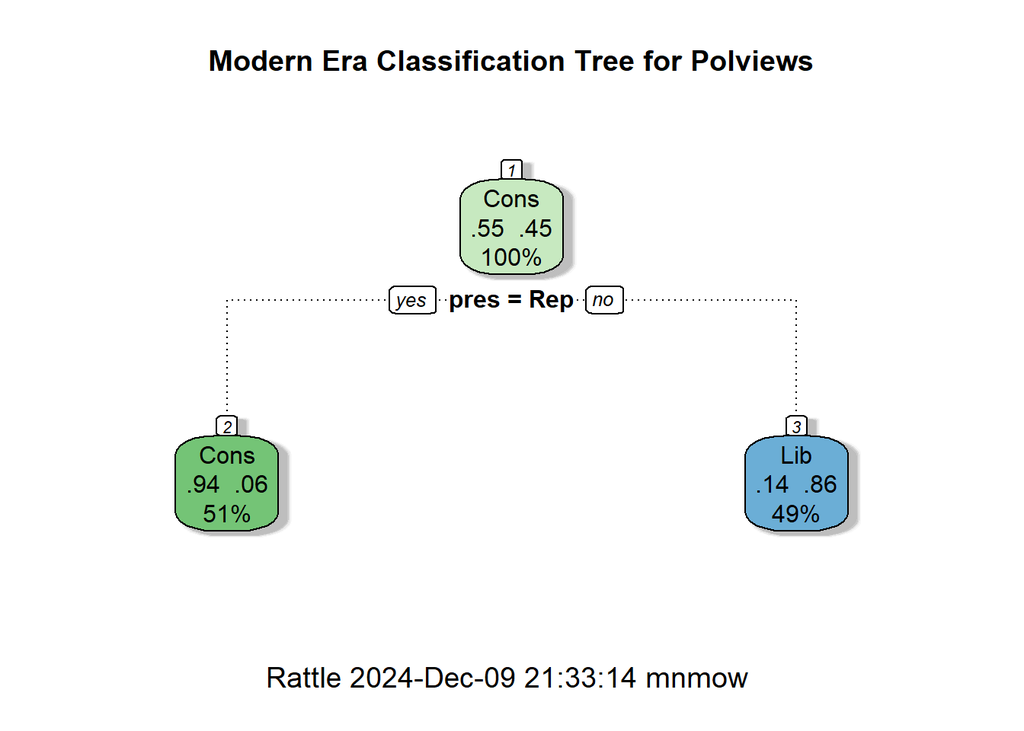

```r
fancyRpartPlot(gssfit, main = "Modern Era Classification Tree for Polviews")
```

```r
# Testing and Validation
pred <- predict(gssfit, gss_test, type = "class")
pmat1 <- confusionMatrix(gss_test$polviews, pred)
pmat1
```

```
## Confusion Matrix and Statistics
##
##           Reference
## Prediction Cons Lib
##       Cons  166  20
##       Lib    14 156
##
##                Accuracy : 0.9045
##                  95% CI : (0.8691, 0.933)
##     No Information Rate : 0.5056
##     P-Value [Acc > NIR] : <2e-16
##
##                   Kappa : 0.8089
##
##  Mcnemar's Test P-Value : 0.3912
##
##             Sensitivity : 0.9222
##             Specificity : 0.8864
##          Pos Pred Value : 0.8925
##          Neg Pred Value : 0.9176
##              Prevalence : 0.5056
##          Detection Rate : 0.4663
##    Detection Prevalence : 0.5225
##       Balanced Accuracy : 0.9043
##
##        'Positive' Class : Cons
##
```

Looking at our results, we can see that the tree method fitted a tree for both time periods. However there differences in shape are interesting. For the model fitted on the prior era data, the tree makes splits at several nodes. However, the model fitted on the current era only made one split, that split being on the pres variable indicating that there is a strong correlation between how a person identifies politically and who they voted for. Let’s compare the accuracy of each model. The model for the older data has an accuracy of 0.640625, while the model for the new data has an accuracy of 0.9044944. We can see that the newer model has a much higher accuracy while only slpitting on one variable. This is a strong indication that the diversity of political identity among voters has shrunk over the years.